# STAT345 - FINAL PROJECT

Ava Woodruff, Marisa Percey, Ethan Leader, Layne Peters

2026-04-21

**Summary of Analysis:**

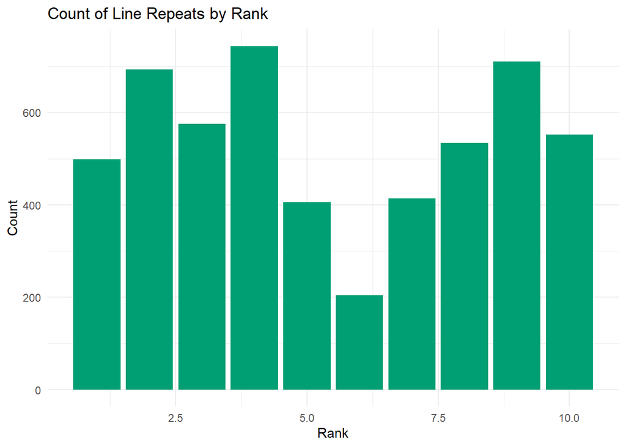

**Analysis:**

The bar chart displays the number of lyrics associated with song ranks from 1 to 10. The distribution is bimodal, with ranks 4 and 9 showing the highest lyric counts, while rank 6 has the lowest. Overall, the counts fluctuate across rankings without a clear upward or downward trend.

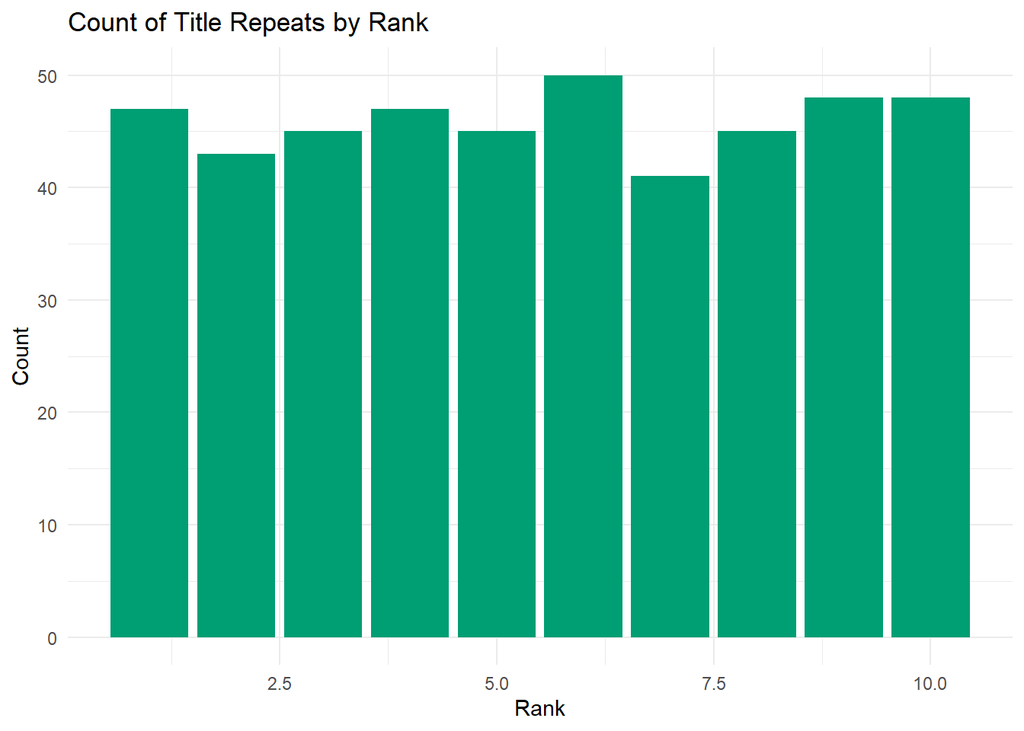

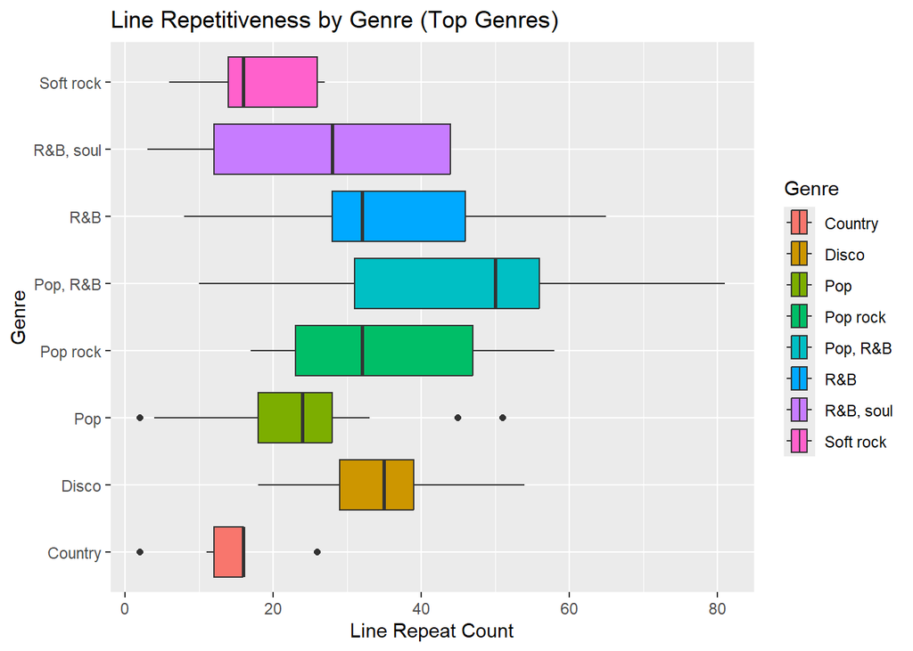

**Analysis:**

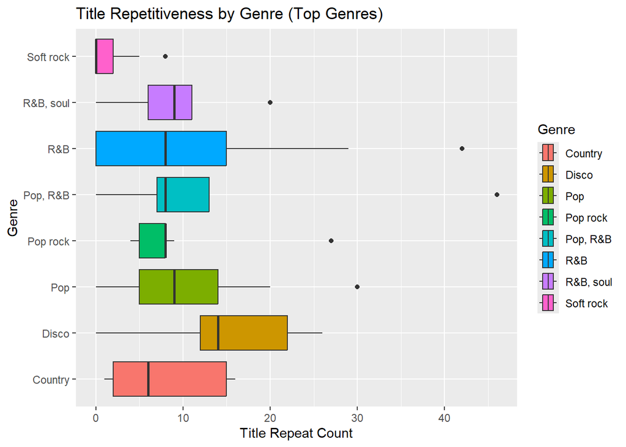

**Analysis:**

The distribution shows that the disco genre has the highest median count for title repetitions at 14, and soft rock has the lowest median count at 0. The rest of the medians all are roughly equal, spanning between 6 and 9 repetitions. Country and R&B have the widest variety of repetitions, as the boxplots are much wider than the rest. R&B and Pop, R&B both have the highest outliers at 40+ title repetitions, which is significantly outside the normal range.

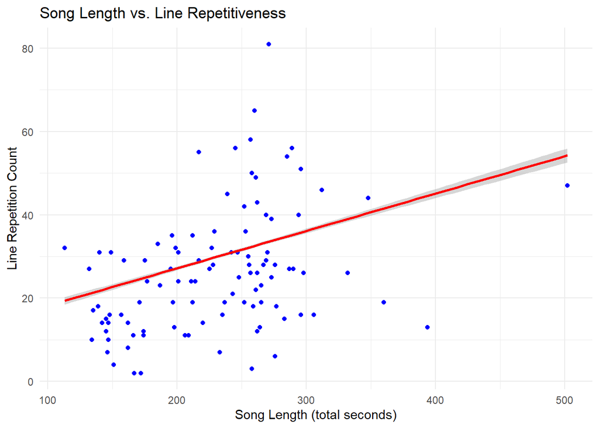

**Analysis:**

The scatter plot shows a weak-to-moderate positive linear relationship between song length and line repetition. While repetitions tend to increase as songs get longer, the high variability suggests that song length is not the only factor determining how repetitive a song is.

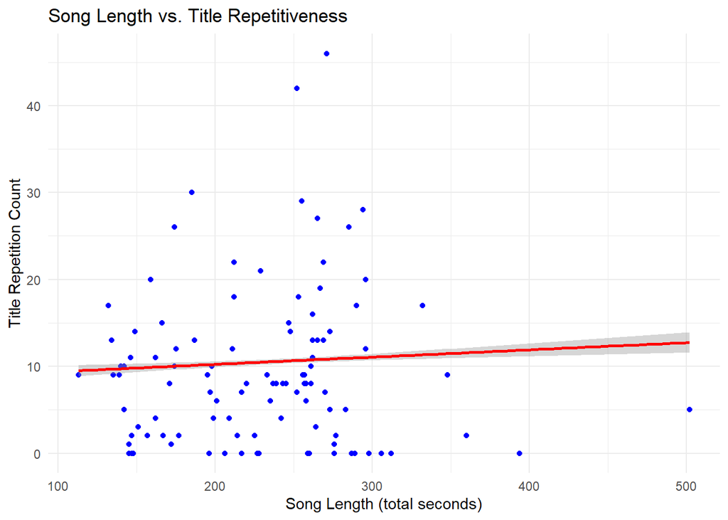

**Analysis:**

The red linear regression line indicates a weak positive correlation between song length and the number of title repetitions throughout a song’s lyrics. As song length increases, the number of repetitions tend to stay low, below 10. The majority of the data falls where song length is between 100 and 300 seconds and title repetition count is between 0 and 20, with a couple outliers peaking at over 40 repetitions.

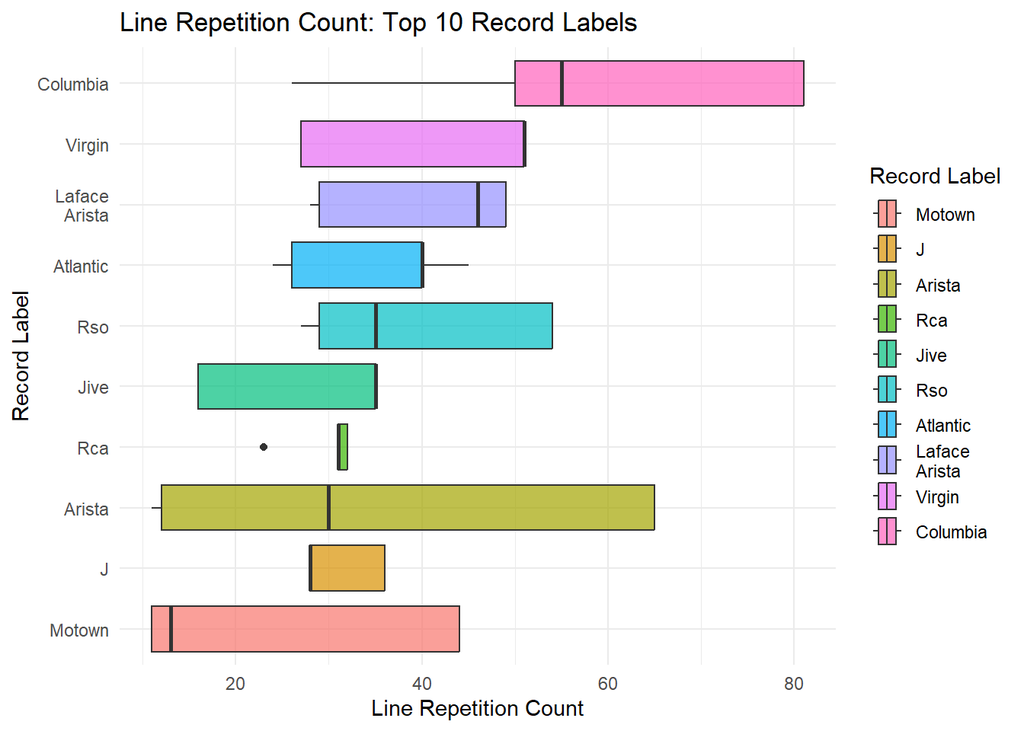

**Analysis:**

The boxplots show that Record Label is a strong predictor of song repetition, with significant differences in “brand style.” Labels like Columbia have the highest typical repetition (median ~55), while Motown is the least repetitive (median ~12). The narrow boxes for Rca and J indicate very consistent songwriting, whereas the wide boxes for Arista suggest a much more varied catalog.

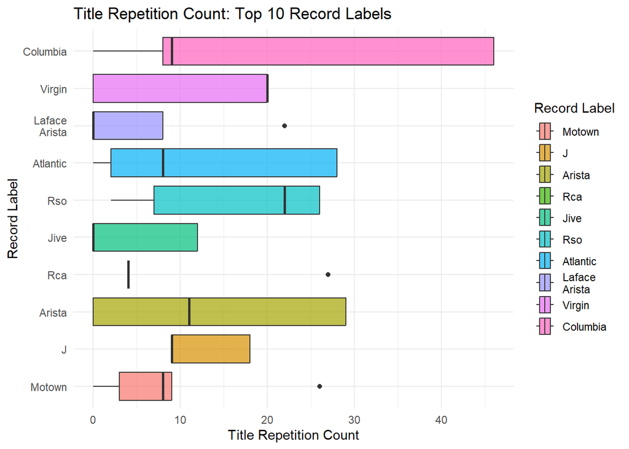

**Analysis:**

The distribution shows a large variety in title repetition count between different record labels. Columbia stands out with the broadest range. Virgin and RSO have the highest medians at 20 and 22, respectively. RCA has the narrowest box, showing a very consistent repetition count, aside from the one outlier. Comparing this plot to the title repetitiveness vs. genre plot, it’s safe to assume that Columbia most likely produces songs in the R&B and Pop, R&B genres seeing as both plots have 40+ repetitions for those values.

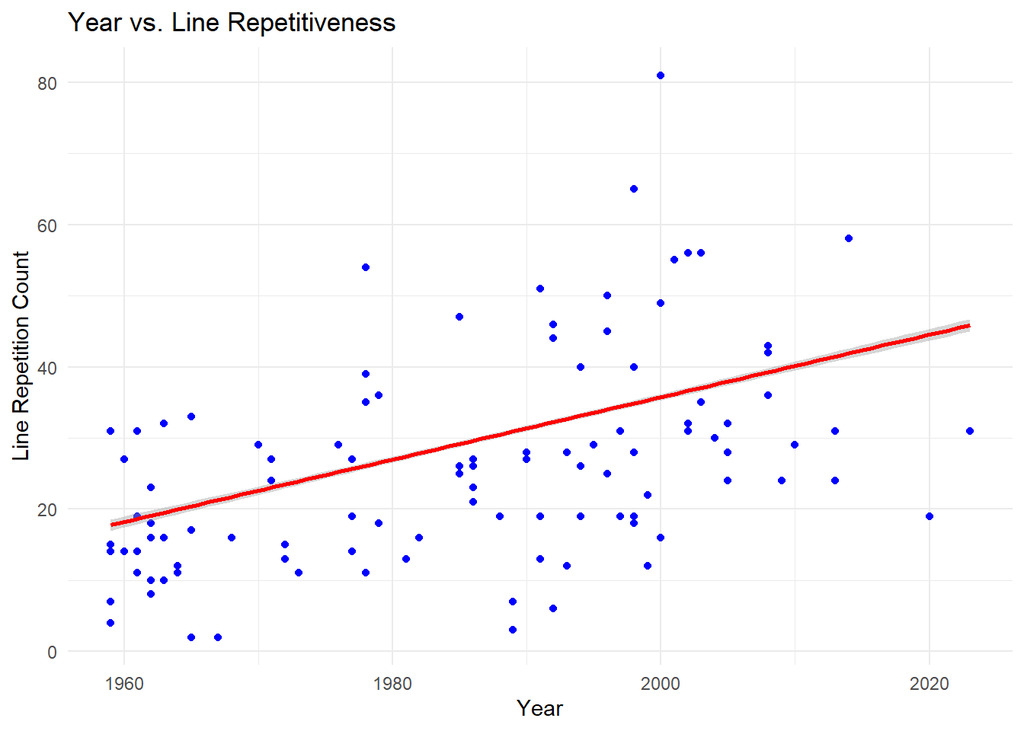

**Analysis:**

This scatter plot shows a positive linear trend over time, suggesting that songs have generally become more repetitive since 1960. While there is significant variation—with some modern songs remaining simple and some older songs being repetitive—the upward slope of the regression line indicates a clear historical shift toward higher line repetition counts in popular music.

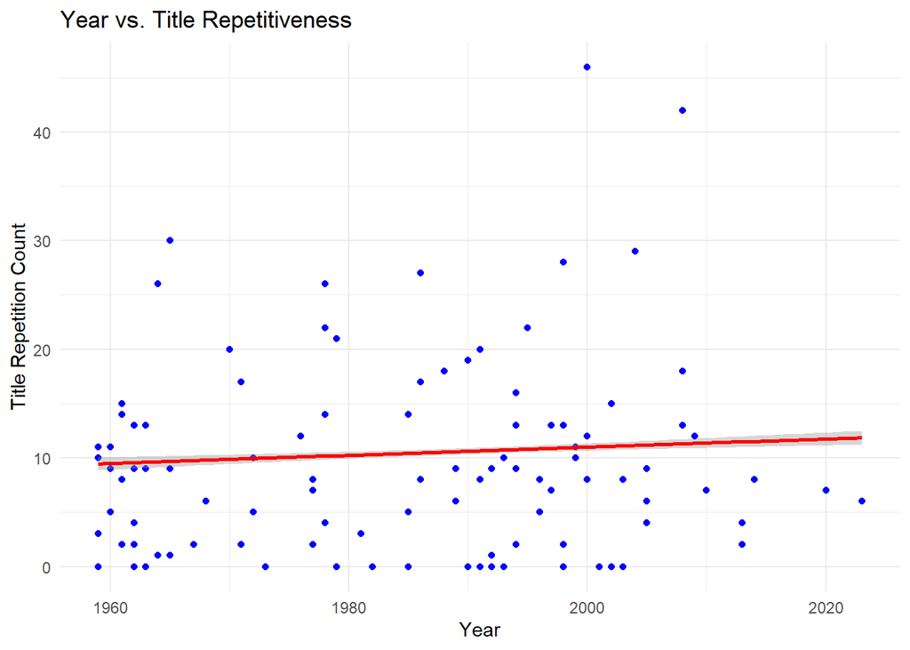

**Analysis:**

The red linear regression line indicates a very weak positive correlation between title repetition count and year, meaning there is little to no increase in songs repeating their title as time progresses. The majority of data points fall between title repetitions of 0 and 15, with two outliers peaking at 40+, significantly outside the normal range, in the 2000s.

**Decision Making / Trouble Shooting:**

- We originally wanted to try and get all top 100 songs from each year, but we ran into the problem of the scraping taking too long and getting denied from running too many requests, being rate limited. We tried added the sleep function to make it take breaks in between requests but it still was denying us some of the scrape requests, to the point where we were missing half of the data. So, we decided to just try the top 10 songs from each year which worked well. To collect sufficient data, we had to attempt scraping multiple times over a few days, starting from where our requests were getting restricted or blocked. In the end, we got the majority of our desired data to scrape successfully.
- When we were constructing the urls to scrape for the songs lyrics, we initially tried scraping from ‘azlyrics.com’, however, we ran into issues with their urls not being consistent. For example, some of the artist names were altered like “The Weekend” became just “Weekend” in the url, so we decided to switch to ‘songlyrics.com’ which had a more consistent url pattern. Another issue we ran into with constructing the url was songs with multiple artists and having various different formats, some used “featuring”, “and”, or just a comma separating the artists, and not all of the artists were listed in the url so we had to filter those out. Some of the older songs just didn’t have a lyrics page either so we couldn’t pull those, plus there was a couple instrumental songs that simply didn’t have lyrics at all. For those cases, which wasn’t a lot, we just made them NA in the tibble and filtered them out before we graphed the results.
- When we scraped the wikipedia pages for the top songs per year there were inconsistencies with the column names. For example, some had “No.” or “№” so we just standardized it to be rank for simplicity sake.
- We also ran into a problem with Ava’s laptop not being able to run more than a couple years of requests at a time. We ended up having just Layne try to run the requests and save the results in a csv file to share with the rest of the group.

**Measuring Repetitions:**

- We ran two different types of repetition measurements; by phrase and by title. For each one, we made a function that would read a csv file of the song lyrics and count the number of times the title or an entire line would repeat throughout the song.
- For measuring by title, the function checks that all required columns exist, because some songs don’t have lyrics, so it’ll just skip over those. Then it cleans/standardizes the text by making it lowercase and removing any punctuation. Then it counts title repetitions in the lyrics for each song, removing songs where the title appears only once or not at all. Finally it returns the filtered data set with the repetition counts included.
- For measuring by phrase, the function separates the lyrics into individual lines, removing any blank lines that separated parts of the song. Then it counts how many times each lyric line repeats in a song, filtering out lines that only appear once, and sorts the songs by rank. Finally, it returns a data set showing the repeated lyric phrases and their counts.